# Modelos de ocorrência: uma espécie, várias estações

Leonardo Wedekin e Paulo Inácio Prado (http://ecologia.ib.usp.br/bie5703)

- Arquivo em pdf
- Arquivo em markdown (para executar os comandos no R studio)

## Preparação

Abra o R e carregue os pacotes necessários

```r
library(unmarked)
library(RMark)
library(stringr)
library(plyr)
```

Usaremos dados de registros da coruja manchada do norte *Strix occidentalis caurina* em 55 sítios de floresta temperada nos EUA, por 5 anos. [Aqui](http://ecologia.ib.usp.br/bie5703/doku.php?id=roteiros:occupancy#exerciciomodelo_de_uma_especie_multiplas_estacoes) há mais informações sobre este caso de estudo.

Os dados estão no formato nativo do MARK (*.inp*). Use os comandos abaixo para convertê-los para um objeto da classe *unmarkedMultFrame*, do pacote *unmarked*:

```r
## Link dos dados na página da disciplina
url <- "http://ecologia.ib.usp.br/bie5703/lib/exe/fetch.php?media=roteiros:corujas.inp"
## Importa arquivo inp
tmp <- convert.inp(url)
## Seleciona historico de capturas e converte em data frame
y <- str_split(tmp$ch, pattern="")
y <- ldply(y, as.numeric)[,2:41]
```

Os dados são de oito visitas anuais, por 5 anos. Temos então que criar covariável que indique o ano de cada visita, que deve ser uma matriz com número de linhas igual ao número de sítios (55 no caso) e número de linhas igual ao número de anos.[^1]

```r
ano <- matrix(data = rep(factor(1998:2002), nrow(y)),
              nrow=nrow(y), ncol=ncol(y)/8, byrow=TRUE)
```

Como neste exemplo não há covariáveis dos sítios nem das visitas já podemos criar o objeto para ajustar o modelo [^2]. Note que o número de ocasiões (anos no caso) deve ser informado no argumento `numPrimary`:

```r
## Cria objeto para o modelo de ocupação multiseason do unmarked
## (Veja vinhetas para detalhes)
coruj <- unmarkedMultFrame(y = y,
                           yearlySiteCovs = list(ano=ano),
                           numPrimary=5)
## Verifica objeto
summary(coruj)
```

```
## unmarkedFrame Object
##
## 55 sites
## Maximum number of observations per site: 40
## Mean number of observations per site: 26.33
## Number of primary survey periods: 5
## Number of secondary survey periods: 8
## Sites with at least one detection: 46
##
## Tabulation of y observations:
##    0    1 <NA>
## 1052  396  752
##
## Yearly-site-level covariates:
##    ano
##  1998:55
##  1999:55
##  2000:55
##  2001:55
##  2002:55
```

## Ajuste dos modelos

O pacote *unmarked* usa a [sintaxe de modelos lineares](http://ecologia.ib.usp.br/bie5782/doku.php?id=bie5782:03_apostila:06-modelos#a_funcao_lm) do R e tem funções para diferentes tipos de modelos de ocupação. Consulte as vinhetas do pacote para mais informações

```r
## Lista da vinhetas
vignette(package="unmarked")
## Abre pdf da vinheta de introdução
vignette(topic="unmarked", package="unmarked")
## Abre pdf da vinheta dos modelos de múltiplas estações
vignette(topic="colext", package="unmarked")
```

Para os modelos de ocupação com covariáveis usamos função *colext*. Seus primeiros quatro argumentos são fórmulas para os parâmetros de ocupação inicial ( $\psi$ ), colonização ( $\gamma$ ), extinção ( $\epsilon$ ) e detecção ( $p$ ).

O modelos mais simples é o que tem todos estes parâmetros constantes:

```r
## ~1 indica constante
coruj.m1 <- colext(psiformula=~1, gammaformula=~1,
                   epsilonformula=~1, pformula=~1,
                   data=coruj)
## Resumo do modelo
summary(coruj.m1)
```

```
##
## Call:
## colext(psiformula = ~1, gammaformula = ~1, epsilonformula = ~1,
##     pformula = ~1, data = coruj)
##
## Initial (logit-scale):
##  Estimate    SE    z P(>|z|)
##     0.537 0.289 1.86   0.063
##
## Colonization (logit-scale):
##  Estimate    SE     z  P(>|z|)
##     -1.49 0.284 -5.23 1.65e-07
##
## Extinction (logit-scale):
##  Estimate   SE     z  P(>|z|)
##     -1.73 0.26 -6.66 2.73e-11
##
## Detection (logit-scale):
##  Estimate     SE      z P(>|z|)
##    -0.021 0.0743 -0.283   0.777
##
## AIC: 1363.32
## Number of sites: 55
## optim convergence code: 0
## optim iterations: 23
## Bootstrap iterations: 0
```

```r
## Coeficientes na escala logito
coef(coruj.m1)
```

```
##    psi(Int)    col(Int)    ext(Int)      p(Int)
##  0.53719570 -1.48831083 -1.72876244 -0.02103079
```

```r
## Intervalos de confiança dos coeficientes
confint(coruj.m1, type='det') #p
```

```
##             0.025     0.975
## p(Int) -0.1667289 0.1246674
```

```r
confint(coruj.m1, type="psi") #psi inicial
```

```
##                0.025    0.975
## psi(Int) -0.02911498 1.103506
```

```r
confint(coruj.m1, type="col") #gamma
```

```
##              0.025      0.975
## col(Int) -2.045534 -0.9310872
```

```r
confint(coruj.m1, type="ext") #epsilon
```

```
##              0.025     0.975
## ext(Int) -2.237498 -1.220027
```

O padrão dos modelos de ocupação é usar a função logito para as probabilidades de detecção e ocupação:

$\text{logit}(p)=\log \left( \frac{p}{1-p} \right)$

Portanto os coeficientes retornados pelas funções `summary` e `coef` estão nesta escala. Para obter as probabilidades estimadas pelo modelo na escala original use a função `backTransform`.

```r
## Coeficientes na escala de probabilidades
(m1.p <- backTransform(coruj.m1, type="det"))
```

```
## Backtransformed linear combination(s) of Detection estimate(s)
##
##  Estimate     SE LinComb (Intercept)
##     0.495 0.0186  -0.021           1
##
## Transformation: logistic
```

```r
(m1.psi= backTransform(coruj.m1, type="psi"))
```

```
## Backtransformed linear combination(s) of Initial estimate(s)
##
##  Estimate     SE LinComb (Intercept)
##     0.631 0.0673   0.537           1
##
## Transformation: logistic
```

```r
(m1.gamma = backTransform(coruj.m1, type="col"))
```

```
## Backtransformed linear combination(s) of Colonization estimate(s)
##
##  Estimate     SE LinComb (Intercept)
##     0.184 0.0427   -1.49           1
##
## Transformation: logistic
```

```r
(m1.epsilon = backTransform(coruj.m1, type="ext"))
```

```
## Backtransformed linear combination(s) of Extinction estimate(s)
##
##  Estimate     SE LinComb (Intercept)
##     0.151 0.0332   -1.73           1
##
## Transformation: logistic
```

```r
## Intervalos de confiança
confint(m1.p)
```

```
##      0.025     0.975
##  0.4584141 0.5311265
```

```r
confint(m1.psi)
```

```
##      0.025     0.975
##  0.4927218 0.7509165
```

```r
confint(m1.gamma)
```

```
##      0.025     0.975
##  0.1145044 0.2827042
```

```r
confint(m1.gamma)
```

```
##      0.025     0.975
##  0.1145044 0.2827042
```

Vamos ajustar um modelo em que detecção e colonização variam entre ocasiões (anos)[^3]:

```r
coruj.m2 <- colext(psiformula=~1, gammaformula=~ano-1,
                   epsilonformula=~1, pformula=~ano-1,
                   data=coruj)
## Resumo do modelo
summary(coruj.m2)
```

```
##
## Call:
## colext(psiformula = ~1, gammaformula = ~ano - 1, epsilonformula = ~1,
##     pformula = ~ano - 1, data = coruj)
##
## Initial (logit-scale):
##  Estimate    SE    z P(>|z|)
##      0.53 0.286 1.85  0.0638
##
## Colonization (logit-scale):
##         Estimate    SE     z P(>|z|)
## ano1998   -2.109 0.768 -2.75 0.00602
## ano1999   -2.541 0.984 -2.58 0.00978
## ano2000   -0.453 0.452 -1.00 0.31590
## ano2001   -2.284 1.050 -2.17 0.02963
##
## Extinction (logit-scale):
##  Estimate    SE     z  P(>|z|)
##     -1.82 0.272 -6.69 2.19e-11
##
## Detection (logit-scale):
##         Estimate    SE      z P(>|z|)
## ano1998   0.3604 0.164  2.203  0.0276
## ano1999   0.0824 0.161  0.511  0.6093
## ano2000  -0.3364 0.180 -1.865  0.0622
## ano2001  -0.5243 0.184 -2.848  0.0044
## ano2002   0.1479 0.157  0.941  0.3469
##
## AIC: 1352.105
## Number of sites: 55
## optim convergence code: 0
## optim iterations: 38
## Bootstrap iterations: 0
```

E agora com a extinção diferente entre ocasiões e colonização constante:

```r
coruj.m3 <- colext(psiformula=~1, gammaformula=~1,
                   epsilonformula=~ano-1, pformula=~ano-1,
                   data=coruj)
## Resumo do modelo
summary(coruj.m3)
```

```
##
## Call:
## colext(psiformula = ~1, gammaformula = ~1, epsilonformula = ~ano -
##     1, pformula = ~ano - 1, data = coruj)
##
## Initial (logit-scale):
##  Estimate    SE    z P(>|z|)
##     0.508 0.285 1.78  0.0746
##
## Colonization (logit-scale):
##  Estimate   SE     z  P(>|z|)
##     -1.51 0.29 -5.21 1.88e-07
##
## Extinction (logit-scale):
##         Estimate    SE     z  P(>|z|)
## ano1998    -2.28 0.625 -3.66 0.000256
## ano1999    -1.92 0.593 -3.23 0.001224
## ano2000    -1.15 0.459 -2.50 0.012381
## ano2001    -1.99 0.592 -3.37 0.000763
##
## Detection (logit-scale):
##         Estimate    SE      z P(>|z|)
## ano1998   0.3678 0.163  2.259  0.0239
## ano1999   0.0838 0.162  0.516  0.6060
## ano2000  -0.3846 0.187 -2.055  0.0399
## ano2001  -0.4317 0.173 -2.496  0.0126
## ano2002   0.1433 0.158  0.905  0.3656
##
## AIC: 1357.025
## Number of sites: 55
## optim convergence code: 0
## optim iterations: 47
## Bootstrap iterations: 0
```

E com extinção e colonização diferentes entre anos:

```r
coruj.m4 <- colext(psiformula=~1, gammaformula=~ano-1,
                   epsilonformula=~ano-1, pformula=~ano-1,
                   data=coruj)
## Resumo do modelo
summary(coruj.m4)
```

```
##
## Call:
## colext(psiformula = ~1, gammaformula = ~ano - 1, epsilonformula = ~ano -
##     1, pformula = ~ano - 1, data = coruj)
##
## Initial (logit-scale):
##  Estimate    SE    z P(>|z|)
##      0.53 0.286 1.86  0.0635
##
## Colonization (logit-scale):
##         Estimate    SE     z P(>|z|)
## ano1998   -2.116 0.770 -2.75 0.00598
## ano1999   -2.599 0.997 -2.61 0.00916
## ano2000   -0.463 0.447 -1.04 0.29981
## ano2001   -2.028 0.843 -2.40 0.01619
##
## Extinction (logit-scale):
##         Estimate    SE     z  P(>|z|)
## ano1998    -2.33 0.623 -3.74 0.000183
## ano1999    -1.87 0.579 -3.22 0.001277
## ano2000    -1.16 0.477 -2.42 0.015343
## ano2001    -2.00 0.593 -3.38 0.000722
##
## Detection (logit-scale):
##         Estimate    SE      z P(>|z|)
## ano1998   0.3613 0.163  2.211 0.02703
## ano1999   0.0773 0.161  0.479 0.63175
## ano2000  -0.3450 0.184 -1.875 0.06075
## ano2001  -0.4715 0.183 -2.576 0.00999
## ano2002   0.1445 0.158  0.913 0.36121
##
## AIC: 1355.65
## Number of sites: 55
## optim convergence code: 0
## optim iterations: 48
## Bootstrap iterations: 0
```

## Seleção de modelos

O *unmarked* tem funções para criar uma lista de modelos e então realizar sua seleção por diversos critérios

```r
modelos <- fitList("p(.)psi(.)e(.)g(.)"=coruj.m1,
                   "p(ano)psi(.)e(.)g(ano)"=coruj.m2,
                   "p(ano)psi(.)e(ano)g(.)"=coruj.m3,
                   "p(ano)psi(.)e(ano)g(ano)"=coruj.m4)
modSel(modelos)
```

```
##                          nPars     AIC delta  AICwt cumltvWt
## p(ano)psi(.)e(.)g(ano)      11 1352.10  0.00 0.7943     0.79
## p(ano)psi(.)e(ano)g(ano)    14 1355.65  3.55 0.1349     0.93
## p(ano)psi(.)e(ano)g(.)      11 1357.03  4.92 0.0678     1.00
## p(.)psi(.)e(.)g(.)           4 1363.32 11.22 0.0029     1.00
```

O modelo de menor AIC ( e portanto $\Delta\text{AIC}=0$) é o mais plausível. Convenciona-se que modelos com $\Delta\text{AIC}\leq2$ são tão plausíveis quanto o selecionado.

## Cálculo do previsto

### Valor previsto dos parâmetros

O modelo com variação de $\gamma$ entre anos é o único com $\Delta\text{AIC}\leq2$. Usamos a função `pred` para estimar os valores de colonização ao longo dos anos:

```r
## primeiro criamos um dataframe com os valores das covariaveis em que faremos as previsões
## Objeto com as covariaveis
df1 <- data.frame(ano=factor(1998:2001))
## Previstos e seus Se e ICs
(coruj.m4.pred <- predict(coruj.m2, type='col', newdata = df1))
```

```
##    Predicted         SE      lower     upper
## 1 0.10824860 0.07410853 0.02625079 0.3534163
## 2 0.07299968 0.06657395 0.01132116 0.3513065
## 3 0.38861130 0.10735206 0.20771917 0.6064519
## 4 0.09246675 0.08811843 0.01284361 0.4437936
```

E um exemplo de gráfico dos previstos e seus intervalos de confiança:

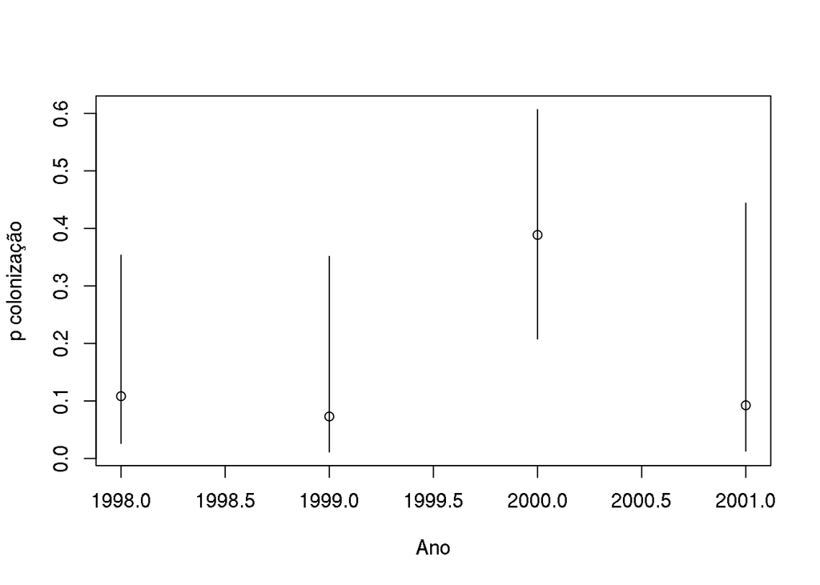

```r
## Juntando os previstos as covariaveis
coruj.m4.pred$ano <- 1998:2001
## Plot de psi x distância para o habitat Creosote
plot(Predicted ~ ano, data=coruj.m4.pred,
     ylim=range(coruj.m4.pred[,3:4]), ylab="p colonização", xlab="Ano")
with(coruj.m4.pred, segments(x0=ano, y0=lower, x1=ano, y1=upper))
```

### Valor previsto de parâmetros derivados

Em que $\phi$ é a probabilidade de persistência ($\phi_i = 1-\epsilon_i$).

Portanto, as probabilidades de ocupação para as ocasiões exceto a primeira são **parâmetros derivados**. O objeto resultante do ajuste já tem estas quantidades guardadas nele. Para vê-las digite

```r
projected(coruj.m2)
```

```
##                    1         2         3         4         5
## unoccupied 0.3704589 0.4181376 0.4687459 0.3606615 0.4164587
## occupied   0.6295411 0.5818624 0.5312541 0.6393385 0.5835413
```

Veja a vinheta do pacote para modelos de múltiplas ocasiões para o cálculo dos intervalos de confiança.

[^1]: neste exemplo a única covariável é a identidade do ano em que ocorreu cada visita. Se há outra covariáveis associadas aos anos basta criar outra matrizes com os valores destas covariáveis com as mesmas dimensões.
[^2]: Veja `help(colext)` e `vignette(topic="colext", package="unmarked")`a para incluir covariáveis de sítios e de visitas.
[^3]: A notação `ano-1` elimina o intercepto da covariável, que corresponde ao primeiro ano. É apenas uma conveniência para ter um coeficiente para cada ano.